# Effects of farming practices on yield and crop water productivity of wheat, maize and potato in China: A meta-analysis - ScienceDirect

## Figures (6)

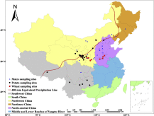

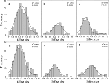

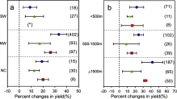

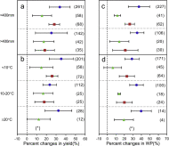

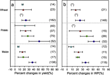

## [Agricultural Water Management](https://www.sciencedirect.com/science/journal/03783774)

[Volume 243](https://www.sciencedirect.com/science/journal/03783774/243/supp/C), 1 January 2021, 106444

# Effects of farming practices on yield and crop water productivity of wheat, maize and potato in China: A meta-analysis

[ShaohuiZhang](https://www.sciencedirect.com/science/article/pii/S037837741932339X#!)[HaidongWang](https://www.sciencedirect.com/science/article/pii/S037837741932339X#!)[XinSun](https://www.sciencedirect.com/science/article/pii/S037837741932339X#!)[JunliangFan](https://www.sciencedirect.com/science/article/pii/S037837741932339X#!)[FucangZhang](https://www.sciencedirect.com/science/article/pii/S037837741932339X#!)[JingZheng](https://www.sciencedirect.com/science/article/pii/S037837741932339X#!)[YuepengLi](https://www.sciencedirect.com/science/article/pii/S037837741932339X#!)

https://doi.org/10.1016/j.agwat.2020.106444[Get rights and content](https://s100.copyright.com/AppDispatchServlet?publisherName=ELS&contentID=S037837741932339X&orderBeanReset=true)

## Highlights

**•**

A comprehensive review on the effects of farming practices on various crops such as wheat, maize and potato

**•**

RFFM performed better than RF and FM in increasing crop yield and crop water productivity.

**•**

Potato obtained the greatest increases in yield and WP under ridge-furrow planting or film mulching.

**•**

For clay soils and high altitude regions, the two film mulching practices (FM and RFFM) attained greater yield increases.

**•**

Under the two ridge-furrow treatments (RFFM and RF), it is better to plant crops in the furrow than on the ridge

## Keywords

Farming practices

Ridge-furrow planting

Film mulching

Yield

Crop water productivity

Meta-analysis

## 1. Introduction

Due to the shortage of water resources and low temperature in spring in many regions of China, the key to improving crop productivity is to maximize the preservation and consumption of soil moisture and to improve crop water productivity (WP) of crops (Ren et al., 2008; Shan and Yan, 2013; Wang et al., 2019a; Zhang et al., 2019a, Zhang et al., 2019). Farming practices such as ridge-furrow planting with plastic film mulching have been widely used in China to improve crop yield and WP by modifying soil hydrothermal micro-environment. Plastic film mulching has a good effect in controlling weeds and increasing soil temperature and moisture (Gan et al., 2013; Duan et al., 2018; Zheng et al., 2018a, 2018b; Wang et al., 2019b, 2019c), while ridge-furrow planting can collect effective or ineffective rainfall (Liang et al., 2018; Zheng et al., 2019). At the same time, strengthening the circulation of soil air by ridges is also a high-efficient farming method to increase crop production. As a new farming practice, ridge-furrow planting with plastic film mulching (RFFM) combines the advantages of both, which improves WP and increases production by employing ridges mulched with plastic film as the runoff area and furrows as the planting area (Eldoma et al., 2016; Zhou et al., 2009; Hu et al., 2014; Gan et al., 2013; Ren et al., 2016; Zheng et al., 2020).

RFFM, ridge-furrow planting without film mulching (RF) and flat planting with film mulching (FM) are three main farming practices for high-efficient rainwater utilization in rain-fed agriculture (Han et al., 2004; Qin et al., 2014; Hu et al., 2014; Zhou et al., 2009). Plastic film mulching can reduce soil water evaporation, conserve and retain limited natural rainfall, thereby maintaining a relatively stable topsoil-moisture content (Tian et al., 2003), reducing fertilizer leaching and increasing emergence rate (Liang et al., 2018; Zhao et al., 2012). The ridges improve the micro-environment of soils (Zhang et al., 2011), prolong the period of moisture availability (Ren et al., 2016), while the furrows not only receive rainwater falling directly on the surface, but also the rainwater runoff from the ridges (Tian et al., 2003). By combining the advantages of both ridge-furrow planting and plastic film mulching, RFFM has been proved to optimize soil water and nutrients status (Ali et al., 2017), promote full release and efficient use of soil rapidly available nutrients (Jeffrey and Taryn, 2012), increase the availability of soil moisture to plant roots (Ren et al., 2016), promote relative growth rate (RGR) and dry matter, and facilitate a higher rate of seedling emergence (Ramakrishna et al., 2006; Zhang et al., 2011; Gan et al., 2013).

Single field trails cannot assess the comprehensive influence of ridge-furrow planting and plastic film mulching on regional and larger scales (Gao et al., 2019). Meta-analysis is a powerful statistical tool to summarize results from numerous single experiments while accounting for variability across experiments (Hedges et al., 1999), and there have been many meta-analysis reports in agricultural studies (Daryanto et al., 2016; Li et al., 2018; Ma et al., 2018; Wang et al., 2015a). Wang et al. (2015a) found that the effect of ridge-furrow mulching was better than flat mulching, and the effect of mulching was better under low rainfall (<150 mm) than under moderate rainfall (150−250 mm) and high rainfall (>250 mm), and put forward that ridge-furrow mulching was the most suitable mulching practice compared with conventional film, straw or other mulching. Li et al. (2018) reported that the improvements of potato yield and WP of film and straw mulching were higher at moderate air temperatures (15–20 °C.) than those at low and high temperatures, and the mean effects of mulching were greater at relatively low or moderate fertilization rates. Gao et al. (2019) recommended that plastic film mulching had the most obvious effect on increasing yield of potato compared with other crops. Ma et al. (2018) indicated that plastic mulching increased soil moisture content and fertilizer residue on the soil surface (0−20 cm), but effectively reduced the organic carbon of 0−10 cm soil layer and did not pose impact on the organic carbon of 10−20 cm soil layer. Yu et al. (2018) indicated that the ridge-furrow planting and plastic film mulching system had the greatest increase in soil water content, soil temperature and grain yield compared with flat cultivation without mulching. All those findings imply that soil mulching is beneficial to nutrient absorption, crop water productivity and yield increase, and film mulching on the ridge is better than that on flat land.

Previous meta-analyses have only studied the effects of film mulching or straw mulching on crops under different climatic regions, temperature, rainfall and nitrogen application rates (Qin et al., 2015; Gao et al., 2019; Wang et al., 2015a; Li et al., 2018; Yu et al., 2018; Ma et al., 2018), while little attention has been paid to the effect of different farming practices such as ridge-furrow planting on crop yield and crop water productivity under various altitudes, soil types and seeding methods. Particularly, a comprehensive review on the effects of farming practices on various crops such as wheat, maize and potato has been lacking. Rice, wheat, maize and potato are the world's major food crops, which play a critical role in China's food production. However, there are very limited field trials on ridge-furrow and film mulching techniques in rice, so only papers on wheat, maize and potato were considered in this study. The main objective of this study was thus to comprehensively evaluate the performances of three major farming practices (RFFM, RF and FM) in comparison with conventional flat planting without film mulching (F) on yield and WP of wheat, maize and potato in China under a range of conditions (i.e., planting region, climatic condition, altitude, soil type and seeding method) based on meta-analysis.

## 2. Materials and methods

### 2.1. Data acquisition

Using Google Scholar (Google Inc., Mountain View, CA, USA), Web of Science (http://apps.webofknowledge.com/) and China National Knowledge Infrastructure (https://www.cnki.net/), we collected published peer-reviewed papers that reported crop yield and crop water productivity as affected by various farming practices under a range of conditions in China from 1980 to 2019, using the following key words: ridge-furrow, cultivation, film mulching, rainfall harvest system, crop yield and crop water productivity. Due to the scarcity of field experiment data in rice, cotton, oilseed and alfalfa, we took no account of those crops in this meta-analysis. This research produced a big database and the papers were screened using the following criteria: (1) field experiment was conducted in China; (2) the study contained the control treatment: conventional flat planting without film mulching (F), and at least one of those three treatments: ridge-furrow planting with film mulching (RFFM), ridge-furrow planting without film mulching (RF) and flat planting with film mulching (FM); (3)The crop water productivity (WP, kg ha<sup>−1</sup> mm<sup>−1</sup>) of mulched or ridged crop was calculated as the ratio of crop yield (kg ha<sup>−1</sup>) to the water consumed by the crop or crop evapotranspiration (ET, mm) in the growing season (Fernándeza et al., 2020; Meng et al., 2020); (4) crop yield and WP for one study had mean and variance, or at least two replicates, or more than two years of data; (5) location, year, planting on the ridge or in the furrow were stated; (6) papers with the same test data to those in the other papers were removed, and the combined effects of various treatments in one study such as fertilization, irrigation and planting density, were ignored; (7) the order of ridges or planting, the color difference of plastic film, and the difference in shape and size of the ridge in the same study were ignored, regardless of whether the ridge was continuously ridged or whether the film was covered both on the ridge and in the furrow or just on the ridge. Finally, 90 papers based on yield and water use efficiency of maize, wheat and potato affected by farming practices were selected and analyzed. Details of the included papers are listed in Appendices A and B.

### 2.2. Data classification

The data were originated from 14 provinces or regions based on administrative divisions, and the same farming practice and climatic condition existed in the same province and region. In order to investigate the responses of yield and WP of maize, wheat and potato to ridge-furrow planting and plastic film mulching: (1) ridge-furrow planting with film mulching (RFFM), ridge-furrow planting without film mulching (RF) and flat planting with film mulching (FM) were compared with traditional flat planting (F) in terms of the improvements in crop yield and WP; (2) the research areas of wheat, maize and potato were divided into six major planting regions: South China (S), Southwest China (SW), Middle and Lower reaches of Yangtze River (MLYR), North-central China (NC), Northeast China (NE) and Northwest China (NW); (3) the altitude of the experimental site were divided into three categories: plain (< 500 m), mountain (500−1500 m) and plateau (≥1500 m); (4) there were two seeding methods, planted on the ridge or in the furrow; (5) three average annual temperature ranges were used during the crop growing period (<10℃, 10−20℃, >20℃); (6) the rainfall amount during the crop growing season was divided into two categories: low (<400 mm) and high (>400 mm); (7) the soil types of cultivated layers used in this study were sandy loam, clay, silty loam, sandy clay loam and loam according to the International System of Soil Classification (USDA 1996). The climatic information for all the planting regions are shown in Table 1, and the field test sites considered in this study are shown in Fig. 1.

Table 1. General climatic information of crop-cultivating regions in China and common cropping systems.

| Region | Annual mean temperature (℃) | Accumulated temperature above 10℃(℃) | Annual sunshine hour (h) | Annual mean rainfall (mm) | Cropping system |
| --- | --- | --- | --- | --- | --- |
| Northeast China | −4 to 12 | 1600−3800 | 2200−2900 | 400−1000 | Single cropping |
| North-central China | 6−15 | 3000−5000 | 2000−2800 | 400−1000 | Single or double cropping |
| Northwest China | −4 to 14 | 2500−5000 | 2000−3300 | 50−800 | Single cropping |
| Middle and Lower reaches of Yangtze River | 10−18 | 4500−6000 | 1100−2500 | 800−1750 | Double cropping |
| South China | 18−24 | 6500−9500 | 1200−2500 | 1000−2500 | Double cropping |
| Southwest China | −4 to 20 | 2000−8000 | 900−2500 | 500−1500 | Single or double cropping |

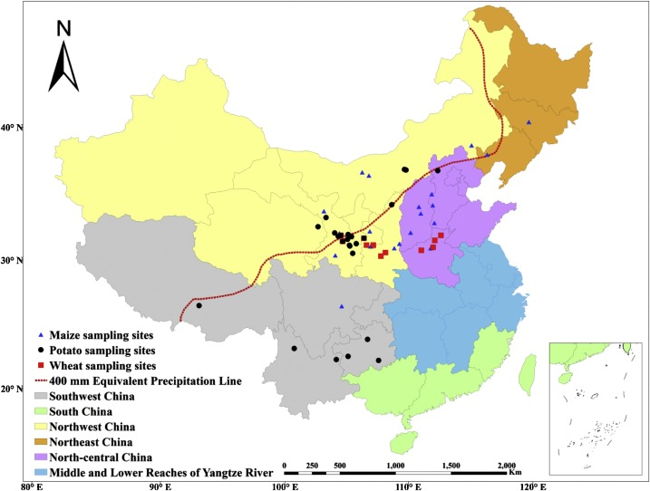

Fig. 1. Geographic regions of maize, potato and wheat cropping in China and locations of field experiments in the literature included in this meta-analysis.

### 2.3. Meta-analysis

Since most studies collected in this study did not provide variance, an unweighted approach proposed by Chen et al. (2013) was considered by using Meta Win 2.1 (Rosenberg et al., 2000). A random-effect model was used to assess the impact of RFFM, RF and FM on crop yield and WP compared with F. When the number of observations was less than 20, bootstrapping with 9999 iterations was used to generate bias corrected 95 % confidence interval(CI) of mean effect sizes because confidence limits based on bootstrapping tests were wider than standard confidence limits (Daryanto et al., 2016). Differences in the mean effect size among groups were calculated using random effect models (Borenstein et al., 2011). The difference was considered significant if the bootstrap confidence interval did not overlap each other. The effect of farming practices was considered significantly different from conventional flat planting (P < 0.05) if the 95 % CI did not reach zero. Groups of the meta-analysis must have at least two valid comparisons.

The frequency distribution of R was plotted to reflect variability of individual study. Meanwhile, the frequency of the R was also fitted to the Gaussian distribution function to test the uniformity of observed data by using Origin v8.0 software. The general linear model-unvariate procedure was performed to determine the effects of each variable on yield and WP of crop using the SPSS statistical software (Version 20.0 for Windows, SPSS, Chicago, USA). Explanatory variables considered in this meta-analysis included planting region, climatic condition, altitude, soil type and seeding method (Supplementary Appendix B).

## 3. Results

### 3.1. Meta-data overview

Our dataset contained 964 observations from 90 studies, including 688 treatment data (RFFM, RF and FM) and 276 control data (F). RFFM, RF and FM had a total of 435, 147 and 106 yield comparison observations with 342, 73 and 91 W P comparison observations, respectively. Maize, potato, wheat had a total of 233, 230 and 227 production comparison observations and 205,107 and 194 W P comparison observations, respectively. Frequency distributions of effect size of relevant data in all studies were found to have a normal distribution (Fig. 2), indicating that the dataset was subject to uniformity. Results of the statistical analysis of the effects of crop type, planting region, rainfall, air temperature, altitude, soil type and seeding method on yield and WP of wheat, maize and potato are summarized in Table 2.

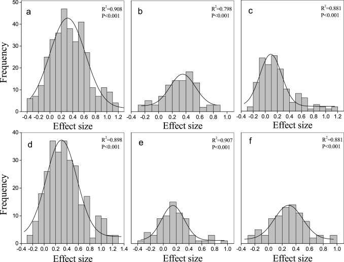

Fig. 2. Frequency distribution of effect sizes for crop yield and WP under RFFM (a, d), FM (b, e) and RF (c, f) in comparison to F. The solid lines are fitted normal (Gaussian) distributions to frequency datasets.

Table 2. Probability values (P) for yield and WP based upon the analysis of variance of experimental data from studies in literature.

| Factors | Dependent variable | FM | RF | RFFM |
| --- | --- | --- | --- | --- |
| Altitude | Y(t ha<sup>−1</sup>) | 0.012* | 0.242 | 0.002** |
| Soil type | Y(t ha<sup>−1</sup>) | 0.312 | 0.722 | 0.006** |
| Climatic region | Y(t ha<sup>−1</sup>) | 0.185 | 0.064 | 0.045* |
| Precipitation | Y(t ha<sup>−1</sup>) | 0.112 | 0.741 | 0.507 |
|  | WP(kg ha<sup>−1</sup> mm<sup>-1</sup>) | 0.183 | 0.875 | 0.130 |
| Temperature | Y(t ha<sup>−1</sup>) | 0.008** | 0.277 | 0.019* |
|  | WP(kg ha<sup>−1</sup> mm<sup>-1</sup>) | 0.749 | 0.962 | 0.488 |
| Planting method | Y(t ha<sup>−1</sup>) | – | 0.080 | 0.008** |
|  | WP(kg ha<sup>−1</sup> mm<sup>-1</sup>) | – | 0.046* | 0.073 |
| Crop | Y(t ha<sup>−1</sup>) | 0.181 | 0.169 | 0.013* |
|  | WP(kg ha<sup>−1</sup> mm<sup>-1</sup>) | 0.252 | 0.165 | 0.000** |

Note: * means significant difference (P < 0.05), ** means very significant difference (P < 0.01).

### 3.2. Responses of crop yield, evapotranspiration and WP to farming practices

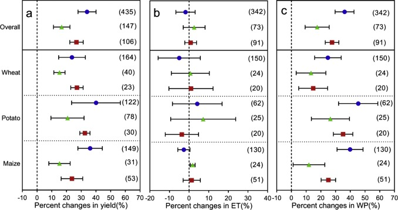

### 3.3. Crop yield and WP as influenced by farming practices in different climatic regions

According to similarity of geographic and climatic conditions, administrative division and analogous natural farming regions of crops in China (Zhao et al., 2016; Xu et al., 2017), the study areas of those crops were divided into six planting regions (Table 1). Crop yield were affected by mulching practices as the planting region changed (Fig. 4a). In Northeast China, there was only one set of data, so it was excluded from this meta-analysis. In general, the ridge-furrow and mulching effect in Northwest China was better than that in other regions, followed by Central China and finally Southwest China. As for RFFM, the highest increase in crop yield was found in Northwest China (33.1 %), followed by North-central China (21.3 %), and the lowest yield increase was obtained in Southwest China (7.7 %). Similar trends were observed under RF and FM. These results are similar to those of Gao’s meta-analysis on the effect of mulching practices (Gao et al., 2019). Under RFFM, the effect of climatic regions on yield reached a significant level (P < 0.05) (Table 2).

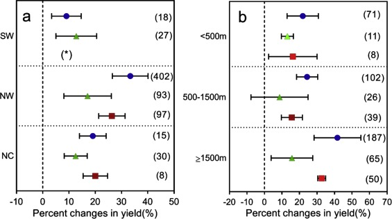

### 3.4. Crop yield as influenced by farming practices under different geographical conditions (altitude and soil type)

In fact, the altitude also affected the effect of farming practices on crop yield (Fig. 4b). At high altitudes (>1500 m), the effect of two mulching practices (FM and RFFM) (41.6 %, 33.1 %) was significantly higher than that of RF (16.2 %) (P < 0.05) (Fig. 4b, Table 2). At high altitudes, the effect of FM and RFFM was better than that at low and medium altitudes, and reached significant level (P < 0.05) (Table 2). However, there was no significant difference between low and medium altitudes. Under RF, the effects at high and low altitudes were better than that at medium altitudes, but there was no significant difference between high and low altitudes.

Under different soil types, the effect of farming practices on yield varied. In this meta-analysis, the cultivated soil layer of the experimental land was subdivided as sandy loam, clay, silty loam, sandy clay loam and loam. The impact of different soil types on crop yield under RFFM, RF and FM is shown in Table 3. In general, clay was most suitable for FM and RFFM to improve crop yield, while loam was most unsuitable. The effects of soil types on the increases in yield under RFFM reached a significant level (P < 0.05) (Table 2). Under RF, sandy clay loam had the best effect, followed by sandy loam. For all soil types except for silty loam, the effect of two mulching practices (RF and RFFM) was significantly better than that of RF, and it reached a significant level for sandy clay loam. For loam and sandy clay loam, the effect of FM (33.0 %, 20.0 %) was slightly better than that of RFFM (28.8 %, 19.1 %), but it was not significant.

Table 3. Effect of ridge-furrow planting and plastic film mulching on crop yield for different soil types (* means no comparison).

| Soil type | Effect (%) | RF 95 % CI (%) | n | FM Effect (%) | FM 95 % CI (%) | FM n | RFFM Effect (%) | RFFM 95 % CI (%) | RFFM n |
| --- | --- | --- | --- | --- | --- | --- | --- | --- | --- |
| Clay | 10.8 | (-9.6, 38.4) | 22 | 39.3 | (38.4, 59.2) | 6 | 66.2 | (33.5, 76.3) | 36 |
| Sandy loam | 17.0 | (-0.9, 33.9) | 26 | 28.5 | (9.9, 35.8) | 12 | 40.5 | (16.8, 67.5) | 46 |
| Silt loam | * | * | * | 23.7 | (-4.8, 27.9) | 9 | 25.7 | (17.6, 33.9) | 54 |
| Sandy clay loam | 17.5 | (2.6, 26.2) | 15 | 33.0 | (26.2, 38.9) | 14 | 28.8 | (17.6, 39.7) | 51 |
| Loam | 11.7 | (-2.3, 31.4) | 31 | 20.0 | (12.4, 28.1) | 50 | 19.1 | (8.3, 29.6) | 132 |

### 3.5. Crop yield and WP as influenced by farming practices under different air temperature and precipitation conditions

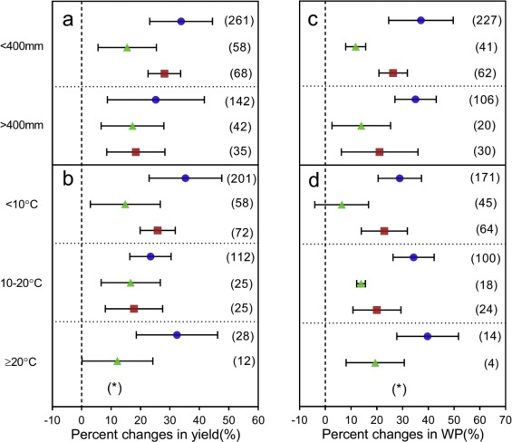

### 3.6. Crop yield and WP as influenced by seeding method for furrow or bed planting

In this study, ridge-furrow planting was generally divided into furrow-planting and bed-planting. In general, the effects of ridge-furrow planting pattern were affected by the location of the planting and it was found that the effect size of the planting in the furrow was significantly larger than that of the bed-planting (Fig. 6). Meanwhile, the effect of different planting methods on yield increases reached a very significant level (P < 0.01) under RFFM, and the effect of different planting methods on WP increase reached a significant level (P < 0.05) under RF (Table 2). On the other hand, the effect of ridge-furrow planting with film mulching (RFFM) on crop yield and WP was greater than that of ridge-furrow planting without film mulching (RF).

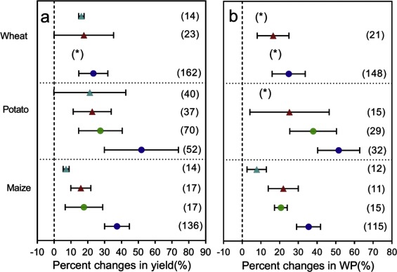

## 4. Discussion

### 4.1. Responses of crop yield, evapotranspiration and WP to farming practices

In terms of potato yield, it was reported that mulched ridge cultivation was more effective than bare ridge cultivation, and bare ridge cultivation was better than flat cultivation (Tian et al., 2003). Eldoma et al., 2016 found that film mulching increased the surface temperature of the soil so as to promote plant growth and the ridges allowed rainwater to flow into the planting belts and furrows, increasing the ability to collect rainwater. Li et al. (2004) suggested that excessive rain and water seepage ensured the supply of deep soil moisture at critical growth periods of the crop. Similar to the conclusions of this meta-analysis, the three farming practices can increase crop yield and crop water productivity. The mean effect of RFFM was larger than RF and FM, and the effect of FM was larger than that of RF. Yu et al. (2018) also concluded that RFFM had better effect on increasing soil temperature, maintaining soil moisture and increasing yield than flat planting with film mulching, ridge-furrow planting with straw mulching and flat planting with straw mulching. Film mulching causes the evaporated air to condense into water droplets, which significantly reduces evaporation from the soil surface (Li et al., 2013). It was also reported that ridge cultivation was able to eliminate or reduce soil crust, greatly improve soil physical conditions and field microclimate, improve nitrogen use efficiency, and reduce crop lodging and the occurrence of some wheat diseases in northern China (Wang et al., 2004). The ridge-furrow planting system with plastic mulching has been shown to reduce rainwater losses, reduce evaporation and improve soil moisture content (Zhao et al., 2014; Ali et al., 2018). Making full use of limited rainwater will inevitably lead to an increase in crop yields. On the other hand, it has been reported that ridges covered with plastic film could significantly extend the duration of photosynthesis and chlorophyll fluorescence and produce higher WP and crop yield (Liao et al., 2005). However, the meta-analysis showed that the differences in seasonal ET of crops were not significant, which was similar to the study of Lian et al. (2016), who found that planting patterns had no effect on crop ET. However, some studies have found that RFFM reduced ET (Li et al., 2019), and some studies have shown that it increased ET (Li et al., 2013). The water consumption of crops is determined by the amount of soil evaporation and transpiration of crop leaves. It has been reported that evaporation dominates ET during the prenatal period, whereas transpiration is the main mechanism of water consumption at the later stage of crop growth (Lian et al., 2016). At the early growth stage of crop, the canopy is small and the film prevents the heat exchange between the soil and the air, reduces the latent heat flux, and at the same time reduces the evaporation of water vapor on the soil surface, which can thus reduce the evaporation compared with the non-film treatment (Ye et al., 2012). On the other hand, ridges significantly increase the surface area of the soil, thereby increasing evaporation. This explains that RF increased the water consumption of crops (Fig. 3b), and their mean effect size was slightly greater than zero. At the late growth stage of crops, all the three practices were better for promoting crop growth compared with F, thereby increasing canopy size and transpiration (Tian et al., 2003; Liang et al., 2018). Therefore, the water consumption of RFFM and FM systems during the whole growing season increased or decreased compared with F, depending on the relationship between effect size (△E) of reduced soil evaporation at the early growth stage and the effect value of increased transpiration during the prosperous season (△T). When ΔT was greater than ΔE, the ET of RFFM or FFM was higher than that of F, and if ΔT was less than ΔE, the ET of RFFM or FFM was lower than that of F (Lian et al., 2016).

### 4.2. Crop yield and WP as influenced by farming practices in different climatic regions (air temperature and rainfall)

The regional differences in crop yield and WP as influenced by ridge-furrow planting and film mulching can be caused by variations in climatic conditions (e.g., accumulated temperature, rainfall and solar radiation). In northern China, especially in the northwest region (semi-arid regions), most of the agricultural cultivation is rain-fed agriculture, and most of them are single cropping system (Table 1, Zhang et al., 2011). Crop production in this area is largely affected by seasonal rainfall amount and its distribution, and water resources are extremely precious and become a major factor affecting crop growth (Liu et al., 2014). The ridge has the function of collecting rainwater, which can enhance the drought-resisting time, and the film can effectively maintain the soil moisture and make full use of the effective and ineffective rainfall, which can alleviate the water shortage in the arid areas (Li et al., 2004). Meanwhile, the cool climate (annual average temperature is lower than 10 °C) makes the northwest region highly ideal for growing potato, cotton and other crops (Gao et al., 2019). Furthermore, the film can increase the soil surface temperature at the earlier growth stages of crops. Similarly, ridges can increase the temperature of the soil by increasing the curvature of the soil surface. Thus, those two framing practices promote the emergence at relatively low temperatures and accelerate crop growth. In northwestern China, RFFM can significantly improve the water utilization by enhancing water infiltration and inhibiting evaporation, and stimulate strong alternation of dry and wet soils to redistribute limited water, so as to ensure the growth of maize during water-sensitive periods (Zhang et al., 2019a, Zhang et al., 2019). Therefore, both ridges-furrow and film mulching have the great potential to increase crop yield and crop water productivity in northwestern China.

### 4.3. Crop yield as influenced by farming practices under different geographical conditions (altitude and soil type)

The growth and production of crops require sufficient heat, rain and nutrients. If the supply is insufficient, it will affect their growth and productivity. Obviously, altitude does not directly affect the physiological growth and production process of crops, but it indirectly affect them by changing the climatic conditions of light, heat, water, fertilizer and so on (Chen, 2010). As an important topographic factor, altitude has a great influence on temperature. Generally speaking, air temperature decreases with the increase of altitude. The temperature decreases about 0.6 ℃ every 100 m above the sea level, and the daily temperature difference also increases gradually, which has an impact on the plant growth process (Pan et al., 2009). However, we have found that mulching had greater potential to promote the growth and development of crops at lower temperatures. This may explain why the two mulching treatments at high altitudes (RFFM: 41.6 %, FM33.1 %) were better than the flat planting in increasing yield than at low-medium elevations and reached a significant level (P < 0.05) (Fig. 4b; Table 2). Another study by Qi et al. (2007) showed that as the altitude continued to increase, the temperature difference between day and night increased. The film can play a role in increasing temperature and moisture, and the content and proportion of photosynthetic pigments such as chlorophyll in the plant increase, which is conducive to enhancing the absorption of light energy.

### 4.4. Crop yield and WP as influenced by seeding method for furrow planting or bed planting

The ridge-furrow rainfall harvesting system is a new type of plastic film mulching cultivation technology, including rain collection zone (ridge) and planting zone (furrow), which is furrow-planting (Gan et al., 2013). The ridge-furrow planting in the furrow creates a three-dimensional canopy due to the existence of ridges and furrows, and a convenient channel for ventilation and light transmission, which is conductive to the accumulation of dry matter. It also reduces runoff due to the accumulation of rainfall, and inhibits soil ineffective evaporation, thereby increasing soil moisture content, crop yield and crop water productivity (Zhang et al., 2013). Wang et al. (2011) found that the soil water storage was greater for furrow-planting than that for bed-planting during the whole growth period. Ren et al. (2007) reported that ridge tillage and furrow planting effectively improved root length, root surface area, root volume and root dry matter weight, which was conductive to the growth and development of maize. Under the furrow-planting mode, the absorption of a large number of elements was higher than that of the flat planting mode, which was related to the concentration of fertilizer in the furrow, where the distance of nutrient transport was short and the nutrient availability around the rhizosphere of maize was higher (Dong et al., 2019). The plants are planted on the ridges, but the rainwater collected is mostly in the furrow. It is difficult for the seeding roots to absorb more soil moisture in the ridges with bed-planting (Liang et al., 2018). The above discussion can explain why the effect of furrow-planting was better than bed-planting, and the effect of planting method on WP was significant (P < 0.05) under RF, and the effect of planting method on yield was extremely significant (P < 0.01) under RFFM (Fig. 6; Table 2).

## Declaration of Competing Interest

The authors report no declarations of interest.

## Acknowledgments

This study was jointly supported by the National Natural Science Foundation of China (51879226, 51579211), the Youth Talent Cultivation Program of Northwest A&F University (No. 2452020010) and the Shaanxi Province Key Industries Innovation Chain Project (2016KTZDNY-01-02).

## Appendix A. Supplementary data

The following are Supplementary data to this article:[Download : Download Word document (25KB)](https://ars.els-cdn.com/content/image/1-s2.0-S037837741932339X-mmc1.docx)[Download : Download spreadsheet (98KB)](https://ars.els-cdn.com/content/image/1-s2.0-S037837741932339X-mmc2.xlsx)

## References

**Ali et al., 2017**

S. Ali, Y. Xu, X. Ma, I. Ahmad, M. Kamran, Z. Dong, T. Cai, Q. Jia, X. Ren, P. Zhang, Z. Jia**Planting patterns and deficit irrigation strategies to improve wheat production and water use efficiency under simulated rainfall conditions**

Front. Plant Sci., 8 (2017), p. 1408

Google Scholar

**Ali et al., 2018**

S. Ali, Y. Xu, Q. Jia, X. Ma, I. Ahmad, M. Adnan, R. Gerard, X. Ren, P. Zhang, T. Cai, J. Zhang, Z. Jia**Interactive effects of plastic film mulching with supplemental irrigation on winter wheat photosynthesis, chlorophyll fluorescence and yield under simulated precipitation conditions**

Agric. Water Manag., 207 (2018), pp. 1-14

[Article](https://www.sciencedirect.com/science/article/pii/S0378377418306358)[Download PDF](https://www.sciencedirect.com/science/article/pii/S0378377418306358/pdfft?md5=359271b03218856452f53cbc073604de&pid=1-s2.0-S0378377418306358-main.pdf)[CrossRef](https://doi.org/10.1155/2018/1615968)[View Record in Scopus](https://www.scopus.com/inward/record.url?eid=2-s2.0-85047840020&partnerID=10&rel=R3.0.0)Google Scholar

**Baghour et al., 2002**

M. Baghour, D.A. Moreno, J. Hernández, N. Castilla, L. Romero**Influence of root temperature on uptake and accumulation of Ni and Co in potato**

J. Plant Physiol., 159 (2002), pp. 1113-1122

[Article](https://www.sciencedirect.com/science/article/pii/S0176161704703314)[Download PDF](https://www.sciencedirect.com/science/article/pii/S0176161704703314/pdf?md5=2f7ede973b68e36a02e21663c2182863&pid=1-s2.0-S0176161704703314-main.pdf)[CrossRef](https://doi.org/10.1078/0176-1617-00547)[View Record in Scopus](https://www.scopus.com/inward/record.url?eid=2-s2.0-0036800811&partnerID=10&rel=R3.0.0)Google Scholar

**Borenstein et al., 2011**

M. Borenstein, L.V. Hedges, J.P.T. Higgins, H.R. Rothstein**Introduction to Meta-analysis**

John Wiley & Sons (2011)

[Google Scholar](https://scholar.google.com/scholar_lookup?title=Introduction%20to%20Meta-analysis&publication_year=2011&author=M.%20Borenstein&author=L.V.%20Hedges&author=J.P.T.%20Higgins&author=H.R.%20Rothstein)

**Chen, 2010**

Z. Chen**On the relationship between geographic latitude and altitude and crop production**

Gansu Agric., 03 (2010), pp. 27-28

[View Record in Scopus](https://www.scopus.com/inward/record.url?eid=2-s2.0-85090322221&partnerID=10&rel=R3.0.0)[Google Scholar](https://scholar.google.com/scholar_lookup?title=On%20the%20relationship%20between%20geographic%20latitude%20and%20altitude%20and%20crop%20production&publication_year=2010&author=Z.%20Chen)

**Chen et al., 2013**

H. Chen, X. Li, F. Hu, W. Shi**Soil nitrous oxide emissions following crop residue addition: a meta-analysis**

Glob. Chang. Biol., 19 (2013), pp. 2956-2964

[CrossRef](https://doi.org/10.1111/gcb.12274)[View Record in Scopus](https://www.scopus.com/inward/record.url?eid=2-s2.0-84883553756&partnerID=10&rel=R3.0.0)Google Scholar

**Daryanto et al., 2016**

S. Daryanto, L. Wang, P.-A. Jacinthe**Drought effects on root and tuber production: a meta-analysis**

Agric. Water Manag., 176 (2016), pp. 122-131

[Article](https://www.sciencedirect.com/science/article/pii/S0378377416301810)[Download PDF](https://www.sciencedirect.com/science/article/pii/S0378377416301810/pdfft?md5=17bb952641867938153f9dba3c5347dc&pid=1-s2.0-S0378377416301810-main.pdf)[View Record in Scopus](https://www.scopus.com/inward/record.url?eid=2-s2.0-84971350899&partnerID=10&rel=R3.0.0)Google Scholar

**Dong et al., 2019**

F. Dong, Q. Yan, F. Li, J. Lu, Y. Jia, F. Yang, M. Wang, J. Zhang, X. Wang, D. Yin**Effects of wide eidge and furrow planting on growth and water use efficiency of summer maize**

Res. Soil Water Conserv., 33 (5) (2019), pp. 266-271

[View Record in Scopus](https://www.scopus.com/inward/record.url?eid=2-s2.0-85090355862&partnerID=10&rel=R3.0.0)Google Scholar

**Dong et al., 2017**

W. Dong, L. Zhang, Y. Duan, L. Sun, P. Zhao, W. van der Werf, J.B. Evers, Q. Wang, R. Wang, Z. Sun**Ridge and furrow systems with film cover increase maize yields and mitigate climate risks of cold and drought stress in continental climates**

Field Crops Res., 207 (2017), pp. 71-78

[Article](https://www.sciencedirect.com/science/article/pii/S037842901630329X)[Download PDF](https://www.sciencedirect.com/science/article/pii/S037842901630329X/pdfft?md5=7873a2f8ce73ab0846e14ffb0a3a906c&pid=1-s2.0-S037842901630329X-main.pdf)[View Record in Scopus](https://www.scopus.com/inward/record.url?eid=2-s2.0-85016151545&partnerID=10&rel=R3.0.0)Google Scholar

**Du et al., 2018**

Y.D. Du, W.Q. Niu, X.-B. Gu, Q. Zhang, B.-J. Cui, Y. Zhao**Crop yield and water use efficiency under aerated irrigation: a meta-analysis**

Agric. Water Manag., 210 (2018), pp. 158-164

[Article](https://www.sciencedirect.com/science/article/pii/S0378377418311302)[Download PDF](https://www.sciencedirect.com/science/article/pii/S0378377418311302/pdfft?md5=c669d87defa7c6cb9853682a032933a3&pid=1-s2.0-S0378377418311302-main.pdf)[View Record in Scopus](https://www.scopus.com/inward/record.url?eid=2-s2.0-85051629857&partnerID=10&rel=R3.0.0)Google Scholar

**Duan et al., 2018**

M. Duan, X. Mao, Z. Xu, Y. Zhao, S. Chen, L. Bo**Effects of water deficit and mulching on leaf gas exchange parameters and yield in seed-maize grain filling stage**

J. Drain. Irrig. Mach. Eng., 36 (11) (2018), pp. 1065-1070

[View Record in Scopus](https://www.scopus.com/inward/record.url?eid=2-s2.0-85064505915&partnerID=10&rel=R3.0.0)Google Scholar

**Eldoma et al., 2016**

I.M. Eldoma, M. Li, F. Zhang, F.M. Li**Alternate or equal ridge–furrow pattern: Which is better for maize production in the rain-fed semi-arid Loess Plateau of China?**

Field Crops Res., 191 (2016), pp. 131-138

[Article](https://www.sciencedirect.com/science/article/pii/S0378429016300508)[Download PDF](https://www.sciencedirect.com/science/article/pii/S0378429016300508/pdfft?md5=bc12ce408cd157107143ee211fc1ce64&pid=1-s2.0-S0378429016300508-main.pdf)[View Record in Scopus](https://www.scopus.com/inward/record.url?eid=2-s2.0-84961223547&partnerID=10&rel=R3.0.0)[Google Scholar](https://scholar.google.com/scholar?q=Alternate%20or%20equal%20ridgefurrow%20pattern:%20Which%20is%20better%20for%20maize%20production%20in%20the%20rain-fed%20semi-arid%20Loess%20Plateau%20of%20China)

**Fernándeza et al., 2020**

J.E. Fernándeza, F. Alconb, A. Diaz-Espejoa, V. Hernandez-Santanaa, M.V. Cuevas**Water use indicators and economic analysis for on-farm irrigation decision:a case study of a super high density olive tree orchard**

Agric. Water Manag., 237 (2020), p. 106074

Google Scholar

**Gan et al., 2013**

Y. Gan, K.H.M. Siddique, N.C. Turner, X.-G. Li, J.-Y. Niu, C. Yang, L. Liu, Q. Chai**Ridge-furrow mulching systems—an innovative technique for boosting crop productivity in semiarid rain-fed environments**

Adv. Agron, Academic Press (2013), pp. 429-476

[Article](https://www.sciencedirect.com/science/article/pii/B9780124059429000074)[Download PDF](https://www.sciencedirect.com/science/article/pii/B9780124059429000074/pdfft?md5=659cb12ea12496b346cb2e4709d97cb1&pid=1-s2.0-B9780124059429000074-main.pdf)[View Record in Scopus](https://www.scopus.com/inward/record.url?eid=2-s2.0-84871486516&partnerID=10&rel=R3.0.0)[Google Scholar](https://scholar.google.com/scholar?q=Ridge-furrow%20mulching%20systemsan%20innovative%20technique%20for%20boosting%20crop%20productivity%20in%20semiarid%20rain-fed%20environments)

**Gao et al., 2019**

H. Gao, C. Yan, Q. Liu, W. Ding, B. Chen, Z. Li**Effects of plastic mulching and plastic residue on agricultural production: a meta-analysis**

Sci. Total Environ., 651 (2019), pp. 484-492

[Article](https://www.sciencedirect.com/science/article/pii/S0048969718335472)[Download PDF](https://www.sciencedirect.com/science/article/pii/S0048969718335472/pdfft?md5=d8967ad31cafd2916a91fa3e4bc8a87b&pid=1-s2.0-S0048969718335472-main.pdf)[View Record in Scopus](https://www.scopus.com/inward/record.url?eid=2-s2.0-85053813100&partnerID=10&rel=R3.0.0)Google Scholar

**Han et al., 2004**

Q. Han, X. Li, J. Wang, J. Jiang, R. Wang, Z. Liu, Z. Jia**Simulated study on soil moisture of field under water micro-collecting farming conditions**

Trans. CSAE, 20 (2) (2004), pp. 78-83

[View Record in Scopus](https://www.scopus.com/inward/record.url?eid=2-s2.0-2942683223&partnerID=10&rel=R3.0.0)Google Scholar

**Hedges et al., 1999**

L.V. Hedges, J. Gurevitch, P.S. Curtis**The meta-analysis of response ratios in experimental ecology**

Ecology, 80 (1999), pp. 1150-1156

[View Record in Scopus](https://www.scopus.com/inward/record.url?eid=2-s2.0-0033037138&partnerID=10&rel=R3.0.0)[Google Scholar](https://scholar.google.com/scholar_lookup?title=The%20meta-analysis%20of%20response%20ratios%20in%20experimental%20ecology&publication_year=1999&author=L.V.%20Hedges&author=J.%20Gurevitch&author=P.S.%20Curtis)

**Hu et al., 2014**

Q. Hu, F. Pan, X. Pan, D. Zhang, N. Yang, Z. Pan, P. Zhao, D. Tuo**Effects of a ridge-furrow micro-field rainwater-harvesting system on potato yield in a semi-arid region**

Field Crops Res., 166 (2014), pp. 92-101

[Article](https://www.sciencedirect.com/science/article/pii/S0378429014001506)[Download PDF](https://www.sciencedirect.com/science/article/pii/S0378429014001506/pdfft?md5=078ca74e7dbc51b992e87c8f83a9da47&pid=1-s2.0-S0378429014001506-main.pdf)[View Record in Scopus](https://www.scopus.com/inward/record.url?eid=2-s2.0-84905560494&partnerID=10&rel=R3.0.0)Google Scholar

**Jeffrey and Taryn, 2012**

S.F. Jeffrey, M.K. Taryn**Effects of soil type, rainfall, straw mulch, and fertilizer on semi-arid vegetation establishment, growth and diversity**

Ecol. Eng., 44 (2012), pp. 70-77

[View Record in Scopus](https://www.scopus.com/inward/record.url?eid=2-s2.0-84958641006&partnerID=10&rel=R3.0.0)Google Scholar

**Li and Gong, 2002**

X.-Y. Li, J.-D. Gong**Effects of different ridge:furrow ratios and supplemental irrigation on crop production in ridge and furrow rainfall harvesting system with mulches**

Agric. Water Manag., 54 (2002), pp. 243-254

[Article](https://www.sciencedirect.com/science/article/pii/S037837740100172X)[Download PDF](https://www.sciencedirect.com/science/article/pii/S037837740100172X/pdfft?md5=3fe6849b2982bad56de1a3ac8cf25753&pid=1-s2.0-S037837740100172X-main.pdf)[View Record in Scopus](https://www.scopus.com/inward/record.url?eid=2-s2.0-0037006951&partnerID=10&rel=R3.0.0)Google Scholar

**Li et al., 2004**

F.-M. Li, P. Wang, J. Wang, J.-Z. Xu**Effects of irrigation before sowing and plastic film mulching on yield and water uptake of spring wheat in semiarid Loess Plateau of China**

Agric. Water Manag., 67 (2004), pp. 77-88

[Article](https://www.sciencedirect.com/science/article/pii/S0378377404000423)[Download PDF](https://www.sciencedirect.com/science/article/pii/S0378377404000423/pdfft?md5=f4ed00a7cf117efe7b1c842b1522a255&pid=1-s2.0-S0378377404000423-main.pdf)[View Record in Scopus](https://www.scopus.com/inward/record.url?eid=2-s2.0-2542539828&partnerID=10&rel=R3.0.0)Google Scholar

**Li et al., 2013**

R. Li, X. Hou, Z. Jia, Q. Han, X. Ren, B. Yang**Effects on soil temperature, moisture, and maize yield of cultivation with ridge and furrow mulching in the rainfed area of the Loess Plateau, China**

Agric. Water Manag., 116 (2013), pp. 101-109

[Article](https://www.sciencedirect.com/science/article/pii/S037837741200248X)[Download PDF](https://www.sciencedirect.com/science/article/pii/S037837741200248X/pdfft?md5=d01e884c928afdf82e253e79bf500ef6&pid=1-s2.0-S037837741200248X-main.pdf)[View Record in Scopus](https://www.scopus.com/inward/record.url?eid=2-s2.0-84870269560&partnerID=10&rel=R3.0.0)Google Scholar

**Li et al., 2018**

Q. Li, H. Li, L. Zhang, S. Zhang, Y. Chen**Mulching improves yield and water-use efficiency of potato cropping in China: a meta-analysis**

Field Crops Res., 221 (2018), pp. 50-60

[Article](https://www.sciencedirect.com/science/article/pii/S0378429017315423)[Download PDF](https://www.sciencedirect.com/science/article/pii/S0378429017315423/pdfft?md5=1b8490b8a9950904292dcdf3cf8f630f&pid=1-s2.0-S0378429017315423-main.pdf)[View Record in Scopus](https://www.scopus.com/inward/record.url?eid=2-s2.0-85042587319&partnerID=10&rel=R3.0.0)Google Scholar

**Li et al., 2019**

W. Li, L. Xiong, C. Wang, Y. Liao, W. Wu**Optimized ridge–furrow with plastic film mulching system to use precipitation efficiently for winter wheat production in dry semi–humid areas**

Agric. Water Manag., 218 (2019), pp. 211-221

[Article](https://www.sciencedirect.com/science/article/pii/S0378377418319206)[Download PDF](https://www.sciencedirect.com/science/article/pii/S0378377418319206/pdfft?md5=e0d80bd73aeadebab24916f432e47839&pid=1-s2.0-S0378377418319206-main.pdf)[View Record in Scopus](https://www.scopus.com/inward/record.url?eid=2-s2.0-85063759547&partnerID=10&rel=R3.0.0)Google Scholar

**Lian et al., 2016**

Y. Lian, S. Ali, X. Zhang, T. Wang, Q. Liu, Q. Jia, Z. Jia, Q. Han**Nutrient and tillage strategies to increase grain yield and water use efficiency in semi-arid areas**

Agric. Water Manag., 178 (2016), pp. 137-147

[Article](https://www.sciencedirect.com/science/article/pii/S0378377416303730)[Download PDF](https://www.sciencedirect.com/science/article/pii/S0378377416303730/pdfft?md5=87616372c6bbdcff16e880085e97269f&pid=1-s2.0-S0378377416303730-main.pdf)[View Record in Scopus](https://www.scopus.com/inward/record.url?eid=2-s2.0-84988890226&partnerID=10&rel=R3.0.0)Google Scholar

**Liang et al., 2018**

Sm. Liang, C. Ren, P.J. Wang, X.T. Wang, Y.S. Li, F.H. Xu, Y. Wang, Y.Q. Dai, L. Zhang, X.P. Li, K. Zhan, Q.F. Yang, Q.J. Sui**Improvements of emergence and tuber yield of potato in a seasonal spring arid region using plastic film mulching only on the ridge**

Field Crops Res., 223 (2018), pp. 57-65

[Article](https://www.sciencedirect.com/science/article/pii/S0378429017320075)[Download PDF](https://www.sciencedirect.com/science/article/pii/S0378429017320075/pdfft?md5=3fecc05f2621e5a404217867a7d5910a&pid=1-s2.0-S0378429017320075-main.pdf)[View Record in Scopus](https://www.scopus.com/inward/record.url?eid=2-s2.0-85045316268&partnerID=10&rel=R3.0.0)Google Scholar

**Liao et al., 2005**

Y. Liao, D. Zhang, Z. Jia, L. Zhang, Y. Lu**Effects of plastic film mulching of Millet on soil moisture and temperature in semi-arid areas in South Ningxia of China**

Agric. Sci. China, 4 (11) (2005), pp. 865-871

[View Record in Scopus](https://www.scopus.com/inward/record.url?eid=2-s2.0-84887073227&partnerID=10&rel=R3.0.0)Google Scholar

**Liu et al., 2014**

X.-E. Liu, X.G. Li, L. Hai, Y.P. Wang, T.-T. Fu, N.C. Turner, F.M. Li**Film-mulched ridge–Furrow management increases maize productivity and sustains soil organic carbon in a dryland cropping system**

Soil Sci. Soc. Am. J., 78 (2014)

[Google Scholar](https://scholar.google.com/scholar?q=Film-mulched%20ridgeFurrow%20management%20increases%20maize%20productivity%20and%20sustains%20soil%20organic%20carbon%20in%20a%20dryland%20cropping%20system)

**Liu et al., 2016**

Z. Liu, J. Xiao, L. Cui**Effects of different ratios of furrow to ridge under ridge film mulching and furrow seeding on water use and yield of spring corn**

Res. Soil and Water Conserv., 23 (1) (2016), pp. 38-44

[View Record in Scopus](https://www.scopus.com/inward/record.url?eid=2-s2.0-85090322581&partnerID=10&rel=R3.0.0)Google Scholar

**Ma et al., 2018**

D. Ma, L. Chen, H. Qu, Y. Wang, T. Misselbrook, R. Jiang**Impacts of plastic film mulching on crop yields, soil water, nitrate, and organic carbon in Northwestern China: a meta-analysis**

Agric. Water Manag., 202 (2018), pp. 166-173

[Article](https://www.sciencedirect.com/science/article/pii/S0378377418300878)[Download PDF](https://www.sciencedirect.com/science/article/pii/S0378377418300878/pdfft?md5=ab01489dc7f936e0b3a648c733226fd9&pid=1-s2.0-S0378377418300878-main.pdf)[View Record in Scopus](https://www.scopus.com/inward/record.url?eid=2-s2.0-85042878053&partnerID=10&rel=R3.0.0)Google Scholar

**Meng et al., 2020**

X. Meng, Y. Lian, Q. Liu, P. Zhang, Z. Jia, Q. Han**Optimizing the planting density under the ridge and furrow rainwater harvesting system to improve crop water productivity for foxtail millet in semiarid areas**

Agric. Water Manag., 238 (2020), p. 106220

[Article](https://www.sciencedirect.com/science/article/pii/S0378377419308364)[Download PDF](https://www.sciencedirect.com/science/article/pii/S0378377419308364/pdfft?md5=7ed4f216d891a9e0876d283fddd12ee1&pid=1-s2.0-S0378377419308364-main.pdf)Google Scholar

**Pan et al., 2009**

H. Pan, M. Li, X. Cai, J. Wu, Z. Du, X. Liu**Responses of growth and ecophsiology of plants to altitude**

Ecol. Environ. Sci., 18 (02) (2009), pp. 722-730

[View Record in Scopus](https://www.scopus.com/inward/record.url?eid=2-s2.0-80955157901&partnerID=10&rel=R3.0.0)Google Scholar

**Qi et al., 2007**

J. Qi, M. Mark, Y. Zhang**The altitudinal variation of leaf traits of Quercus liaotungensis and associated environmental explanations**

Acta Ecol. Sin., 03 (2007), pp. 930-937

[View Record in Scopus](https://www.scopus.com/inward/record.url?eid=2-s2.0-67650941247&partnerID=10&rel=R3.0.0)Google Scholar

**Qin et al., 2014**

S. Qin, J. Zhang, H. Dai, D. Wang, D. Li**Effect of ridge–furrow and plastic-mulching planting patterns on yield formation and water movement of potato in a semi-arid area**

Agric. Water Manag., 131 (2014), pp. 87-94

[Article](https://www.sciencedirect.com/science/article/pii/S0378377413002564)[Download PDF](https://www.sciencedirect.com/science/article/pii/S0378377413002564/pdfft?md5=5dd0c78988e962acab2cb4523ea8d42d&pid=1-s2.0-S0378377413002564-main.pdf)[View Record in Scopus](https://www.scopus.com/inward/record.url?eid=2-s2.0-84885455790&partnerID=10&rel=R3.0.0)[Google Scholar](https://scholar.google.com/scholar?q=Effect%20of%20ridgefurrow%20and%20plastic-mulching%20planting%20patterns%20on%20yield%20formation%20and%20water%20movement%20of%20potato%20in%20a%20semi-arid%20area)

**Qin et al., 2015**

W. Qin, C. Hu, O. Oenema**Soil mulching significantly enhances yields and water and nitrogen use efficiencies of maize and wheat: a meta-analysis**

Sci. Rep., 5 (2015), p. 16210

Google Scholar

**Ramakrishna et al., 2006**

A. Ramakrishna, H.M. Tam, S.P. Wani, T.D. Long**Effect of mulch on soil temperature, moisture, weed infestation and yield of groundnut in northern Vietnam**

Field Crops Res., 95 (2006), pp. 115-125

[Article](https://www.sciencedirect.com/science/article/pii/S0378429005000560)[Download PDF](https://www.sciencedirect.com/science/article/pii/S0378429005000560/pdfft?md5=220117ad598048c8d694ffcbca8e42ea&pid=1-s2.0-S0378429005000560-main.pdf)[View Record in Scopus](https://www.scopus.com/inward/record.url?eid=2-s2.0-30044449467&partnerID=10&rel=R3.0.0)Google Scholar

**Ren et al., 2007**

X. Ren, Z. Jia, X. Chen, J. Han, J. Han**Effect of ridge and furrow planting of rainfall harvesting on soil available nutrient distribution and root growth of summer corn under simulated rainfall conditions**

Trans. CSAE, 23 (12) (2007), pp. 94-99

[View Record in Scopus](https://www.scopus.com/inward/record.url?eid=2-s2.0-38049182990&partnerID=10&rel=R3.0.0)Google Scholar

**Ren et al., 2008**

X. Ren, Z. Jia, X. Chen**Rainfall concentration for increasing corn production under semiarid climate**

Agric. Water Manag., 95 (2008), pp. 1293-1302

[Article](https://www.sciencedirect.com/science/article/pii/S0378377408001455)[Download PDF](https://www.sciencedirect.com/science/article/pii/S0378377408001455/pdfft?md5=a9e8aacc929d8ab61b1ff78c53598d01&pid=1-s2.0-S0378377408001455-main.pdf)[View Record in Scopus](https://www.scopus.com/inward/record.url?eid=2-s2.0-55249121638&partnerID=10&rel=R3.0.0)Google Scholar

**Ren et al., 2016**

X. Ren, T. Cai, X. Chen, P. Zhang, Z. Jia**Effect of rainfall concentration with different ridge widths on winter wheat production under semiarid climate**

Eur. J. Agron., 77 (2016), pp. 20-27

[Article](https://www.sciencedirect.com/science/article/pii/S1161030116300533)[Download PDF](https://www.sciencedirect.com/science/article/pii/S1161030116300533/pdfft?md5=3f7ec192ca4a0f6be81e192d52291711&pid=1-s2.0-S1161030116300533-main.pdf)[View Record in Scopus](https://www.scopus.com/inward/record.url?eid=2-s2.0-84961894404&partnerID=10&rel=R3.0.0)Google Scholar

**Rosenberg et al., 2000**

M.S. Rosenberg, D.C. Adams, J. Gurevitch**Metawin: Statistical Software for Meta-analysis. Version 2.1**

Sinauer Associates, Sunderland (Massachusetts) (2000)

Google Scholar

**Shan and Yan, 2013**

J. Shan, X. Yan**Effects of crop residue returning on nitrous oxide emissions in agricultural soils**

Atmos. Environ., 71 (2013), pp. 170-175

[Article](https://www.sciencedirect.com/science/article/pii/S1352231013001106)[Download PDF](https://www.sciencedirect.com/science/article/pii/S1352231013001106/pdfft?md5=41671633b5615a450712d7f6e62caa37&pid=1-s2.0-S1352231013001106-main.pdf)[View Record in Scopus](https://www.scopus.com/inward/record.url?eid=2-s2.0-84874731351&partnerID=10&rel=R3.0.0)[Google Scholar](https://scholar.google.com/scholar_lookup?title=Effects%20of%20crop%20residue%20returning%20on%20nitrous%20oxide%20emissions%20in%20agricultural%20soils&publication_year=2013&author=J.%20Shan&author=X.%20Yan)

**Tian et al., 2003**

Y. Tian, D. Su, F. Li, X. Li**Effect of rainwater harvesting with ridge and furrow on yield of potato in semiarid areas**

Field Crops Res., 84 (2003), pp. 385-391

[Article](https://www.sciencedirect.com/science/article/pii/S0378429003001187)[Download PDF](https://www.sciencedirect.com/science/article/pii/S0378429003001187/pdfft?md5=841393d130fd4677c50f84ca28cf8f83&pid=1-s2.0-S0378429003001187-main.pdf)[View Record in Scopus](https://www.scopus.com/inward/record.url?eid=2-s2.0-0345166824&partnerID=10&rel=R3.0.0)Google Scholar

**Wang et al., 2004**

F. Wang, X. Wang, S. Ken**Comparison of conventional, flood irrigated, flat planting with furrow irrigated, raised bed planting for winter wheat in China**

Field Crops Res., 87 (2004), pp. 35-42

[View Record in Scopus](https://www.scopus.com/inward/record.url?eid=2-s2.0-84878317624&partnerID=10&rel=R3.0.0)Google Scholar

**Wang et al., 2006**

H. Wang, Y. Ma, T. Ning, C. Zhao, N. Jiao, Z. Liu, Z. Li**Effect on quality traits and grain yield of the high-quality wheat in different types of soils**

J. Shihezi Univ. (Nat. Sci.), 01 (2006), pp. 75-78

[View Record in Scopus](https://www.scopus.com/inward/record.url?eid=2-s2.0-72049093379&partnerID=10&rel=R3.0.0)Google Scholar

**Wang et al., 2011**

T.-C. Wang, L. Wei, H.-Z. Wang, S.-C. Ma, B.L. Ma**Responses of rainwater conservation, precipitation-use efficiency and grain yield of summer maize to a furrow-planting and straw-mulching system in northern China**

Field Crops Res., 124 (2011), pp. 223-230

[Article](https://www.sciencedirect.com/science/article/pii/S0378429011002218)[Download PDF](https://www.sciencedirect.com/science/article/pii/S0378429011002218/pdfft?md5=40e49b25b5718c10924287196fc0bbde&pid=1-s2.0-S0378429011002218-main.pdf)[View Record in Scopus](https://www.scopus.com/inward/record.url?eid=2-s2.0-80052647751&partnerID=10&rel=R3.0.0)Google Scholar

**Wang et al., 2013**

G. Wang, D. Yang, L. Li, J. Huang, X. Tang, D. Wei**Effects of different texture soils on growth, development and yield of high-yielding wheat**

Shandong Agric. Sci., 45 (11) (2013), pp. 84-86

[View Record in Scopus](https://www.scopus.com/inward/record.url?eid=2-s2.0-85090335984&partnerID=10&rel=R3.0.0)Google Scholar

**Wang et al., 2015**

Q. Wang, B. Chang, B. Sun, Pan. Gao, F. Liu, Z. Gao**Effects of different soil types on yield and nutrient absorption characters of rice**

Crops, 3 (2015), pp. 116-121

[View Record in Scopus](https://www.scopus.com/inward/record.url?eid=2-s2.0-85047371888&partnerID=10&rel=R3.0.0)Google Scholar

**Wang et al., 2015a**

L.F. Wang, J. Chen, Z.P. Shangguan**Yield responses of wheat to mulching practices in dryland farming on the Loess Plateau**

PLoS One, 28 (5) (2015), p. e0127402

[CrossRef](https://doi.org/10.1371/journal.pone.0127402)Google Scholar

**Wang et al., 2019a**

X. Wang, J. Fan, Y. Xing, G. Xu, H. Wang, J. Deng, Y. Wang, F. Zhang, P. Li, Z. Li**The effects of mulch and nitrogen fertilizer on the soil environment of crop plants**

Adv. Agron., 153 (2019), pp. 121-173

[Article](https://www.sciencedirect.com/science/article/pii/S0065211318300786)[Download PDF](https://www.sciencedirect.com/science/article/pii/S0065211318300786/pdfft?md5=447aa4213093b30b1da8c8712c83e1a4&pid=1-s2.0-S0065211318300786-main.pdf)[View Record in Scopus](https://www.scopus.com/inward/record.url?eid=2-s2.0-85054187657&partnerID=10&rel=R3.0.0)Google Scholar

**Wang et al., 2019b**

H. Wang, X. Wang, L. Bi, Y. Wang, J. Fan, F. Zhang, X. Hou, M. Cheng, W. Hu, L. Wu, Y. Xiang**Multi-objective optimization of water and fertilizer management for potato production in sandy areas of northern China based on TOPSIS**

Field Crops Res., 240 (2019), pp. 55-68

[Article](https://www.sciencedirect.com/science/article/pii/S037842901831459X)[Download PDF](https://www.sciencedirect.com/science/article/pii/S037842901831459X/pdfft?md5=784785843ec97f452f179bad978f82eb&pid=1-s2.0-S037842901831459X-main.pdf)[View Record in Scopus](https://www.scopus.com/inward/record.url?eid=2-s2.0-85067260923&partnerID=10&rel=R3.0.0)Google Scholar

**Wang et al., 2019c**

K. Wang, Y. Li, H. Fang, L. Du, L. Xu**Effects of plastic-film mulching and supplementary irrigation on yield and water use efficiency of winter wheat**

J. Drain. Irrig. Mach. Eng., 37 (8) (2019), pp. 718-723

[View Record in Scopus](https://www.scopus.com/inward/record.url?eid=2-s2.0-85071753132&partnerID=10&rel=R3.0.0)Google Scholar

**Xu et al., 2017**

X. Xu, P. He, J. Zhang, M.F. Pampolino, A.M. Johnston, W. Zhou**Spatial variation of attainable yield and fertilizer requirements for maize at the regional scale in China**

Field Crops Res., 203 (2017), pp. 8-15

[Article](https://www.sciencedirect.com/science/article/pii/S0378429016307547)[Download PDF](https://www.sciencedirect.com/science/article/pii/S0378429016307547/pdfft?md5=1344c7fb68b35180927b3ea759b5392c&pid=1-s2.0-S0378429016307547-main.pdf)[View Record in Scopus](https://www.scopus.com/inward/record.url?eid=2-s2.0-85006165445&partnerID=10&rel=R3.0.0)Google Scholar

**Ye et al., 2012**

J. Ye, F. Zhang, G. Sun**Mapping the rain use efficiency of maize under three management practices on the Chinese loess plateau**

2012 First International Conference on Agro- Geoinformatics (Agro-Geoinformatics) (2012), pp. 1-5

[CrossRef](https://doi.org/10.1109/Agro-Geoinformatics.2012.6311697)[View Record in Scopus](https://www.scopus.com/inward/record.url?eid=2-s2.0-84905273440&partnerID=10&rel=R3.0.0)Google Scholar

**Yu et al., 2018**

Y. Yu, N. Turner, Y. Gong, F. Li, C. Fang, L. Ge, J. Ye**Benefits and limitations to straw- and plastic-film mulch on maize yield and water use effi ciency: a meta-analysis across hydrothermal gradients**

Eur. J. Agron., 99 (2018), pp. 138-147

[Article](https://www.sciencedirect.com/science/article/pii/S1161030118302971)[Download PDF](https://www.sciencedirect.com/science/article/pii/S1161030118302971/pdfft?md5=a42f1a5b3aee9550a5657ea80068febb&pid=1-s2.0-S1161030118302971-main.pdf)[View Record in Scopus](https://www.scopus.com/inward/record.url?eid=2-s2.0-85050075776&partnerID=10&rel=R3.0.0)Google Scholar

**Zhang et al., 2019**

S. Zhang, Y. Li, J. Li**Effects of film-uncovering time on soil enzyme activity and maize nitrogen uptake under drip irrigation**

J. Drain. Irrig. Mach. Eng., 37 (5) (2019), pp. 454-460

[View Record in Scopus](https://www.scopus.com/inward/record.url?eid=2-s2.0-85069580048&partnerID=10&rel=R3.0.0)Google Scholar

**Zhang et al., 2011**

S. Zhang, P. Li, X. Yang, Z. Wang, X. Chen**Effects of tillage and plastic mulch on soil water, growth and yield of spring-sown maize**

Soil Tillage Res., 112 (2011), pp. 92-97

[Article](https://www.sciencedirect.com/science/article/pii/S0167198710002217)[Download PDF](https://www.sciencedirect.com/science/article/pii/S0167198710002217/pdfft?md5=911042989f93ac74d9befddb2e0e2f25&pid=1-s2.0-S0167198710002217-main.pdf)[View Record in Scopus](https://www.scopus.com/inward/record.url?eid=2-s2.0-78651486625&partnerID=10&rel=R3.0.0)Google Scholar

**Zhang et al., 2013**

T. Zhang, P. WU, X. Zhao, F. Zhang, Z. Wang**Effects of ridge and furrow planting system on growth and yield of maize**

Agric. Res. Arid Areas, 31 (1) (2013), pp. 27-31

[CrossRef](https://doi.org/10.4236/eng.2013.510B006)[View Record in Scopus](https://www.scopus.com/inward/record.url?eid=2-s2.0-84966527347&partnerID=10&rel=R3.0.0)Google Scholar

**Zhang et al., 2017**

J. Zhang, H. Wang, J. Liu, H. Chen, Y. Du, J. Li, H. Sun, T. Peng, Q. Zhao**Influence of water potential and soil type on conventional japonica super rice yield and soil enzyme activities**

J. Integr. Agric., 16 (5) (2017), pp. 1044-1052

[Article](https://www.sciencedirect.com/science/article/pii/S2095311916615757)[Download PDF](https://www.sciencedirect.com/science/article/pii/S2095311916615757/pdf?md5=269161913464d97fd8d3fc9e4de28e7d&pid=1-s2.0-S2095311916615757-main.pdf)[View Record in Scopus](https://www.scopus.com/inward/record.url?eid=2-s2.0-85019049139&partnerID=10&rel=R3.0.0)Google Scholar

**Zhang et al., 2019a**

X. Zhang, J. Zhao, L. Yang, M. Kamran, X. Xue, Z. Dong, Z. Jia, Q. Han**Ridge-furrow mulching system regulates diurnal temperature amplitude and wetting-drying alternation behavior in soil to promote maize growth and water use in a semiarid region**

Field Crops Res., 233 (2019), pp. 121-130

[Article](https://www.sciencedirect.com/science/article/pii/S0378429018313224)[Download PDF](https://www.sciencedirect.com/science/article/pii/S0378429018313224/pdfft?md5=fada7eb48326a12107e5b56a5d86c4c9&pid=1-s2.0-S0378429018313224-main.pdf)[CrossRef](https://doi.org/10.3847/1538-4357/ab09f4)[View Record in Scopus](https://www.scopus.com/inward/record.url?eid=2-s2.0-85059105292&partnerID=10&rel=R3.0.0)Google Scholar

**Zhao and Song, 2008**

X. Zhao, C. Song**Analysis of soil, fertilizer and water conditions for high and stable wheat production**

J. Shandong Agric. Admin. Coll., 04 (2008), pp. 164-165

[View Record in Scopus](https://www.scopus.com/inward/record.url?eid=2-s2.0-85090359838&partnerID=10&rel=R3.0.0)Google Scholar

**Zhao et al., 2012**

H. Zhao, Y.-C. Xiong, F.-M. Li, R.-Y. Wang, S.-C. Qiang, T.-F. Yao, F. Mo**Plastic film mulch for half growing-season maximized WUE and yield of potato via moisture-temperature improvement in a semi-arid agroecosystem**

Agric. Water Manag., 104 (2012), pp. 68-78

[Article](https://www.sciencedirect.com/science/article/pii/S0378377411003210)[Download PDF](https://www.sciencedirect.com/science/article/pii/S0378377411003210/pdfft?md5=966ceebeebd08416c3be7018a3999416&pid=1-s2.0-S0378377411003210-main.pdf)[View Record in Scopus](https://www.scopus.com/inward/record.url?eid=2-s2.0-84855841885&partnerID=10&rel=R3.0.0)Google Scholar

**Zhao et al., 2014**

H. Zhao, R.-Y. Wang, B.-L. Ma, Y.-C. Xiong, S.-C. Qiang, C.-L. Wang, C.-A. Liu, F.-M. Li**Ridge-furrow with full plastic film mulching improves water use efficiency and tuber yields of potato in a semiarid rainfed ecosystem**

Field Crops Res., 161 (2014), pp. 137-148

[Article](https://www.sciencedirect.com/science/article/pii/S0378429014000513)[Download PDF](https://www.sciencedirect.com/science/article/pii/S0378429014000513/pdfft?md5=35819c83a1db177c45ce13ab7b1d9de7&pid=1-s2.0-S0378429014000513-main.pdf)[View Record in Scopus](https://www.scopus.com/inward/record.url?eid=2-s2.0-84898831275&partnerID=10&rel=R3.0.0)Google Scholar

**Zhao et al., 2016**

J. Zhao, Y. Zhang, Y. Qian, Z. Pan, Y. Zhu, Y. Zhang, J. Guo, L. Xu**Coincidence of variation in potato yield and climate in northern China**

Sci. Total Environ., 573 (2016), pp. 965-973

[Article](https://www.sciencedirect.com/science/article/pii/S0048969716318988)[Download PDF](https://www.sciencedirect.com/science/article/pii/S0048969716318988/pdfft?md5=2088f87a720a113c1b528fa8ebaf7683&pid=1-s2.0-S0048969716318988-main.pdf)[View Record in Scopus](https://www.scopus.com/inward/record.url?eid=2-s2.0-84985031064&partnerID=10&rel=R3.0.0)Google Scholar

**Zheng et al., 2018a**

J. Zheng, J. Fan, F. Zhang, S. Yan, J. Guo, D. Chen, Z. Li**Mulching mode and planting density affect canopy interception loss of rainfall and water use efficiency of dryland maize on the Loess Plateau of China**

J. Arid Land, 10 (5) (2018), pp. 794-808

[CrossRef](https://doi.org/10.1007/s40333-018-0122-y)[View Record in Scopus](https://www.scopus.com/inward/record.url?eid=2-s2.0-85053856179&partnerID=10&rel=R3.0.0)Google Scholar

**Zheng et al., 2018b**

J. Zheng, J. Fan, F. Zhang, S. Yan, Y. Xiang**Rainfall partitioning into throughfall, stemflow and interception loss by maize canopy on the semi-arid Loess Plateau of China**

Agric. Water Manag., 195 (2018), pp. 25-36

[Article](https://www.sciencedirect.com/science/article/pii/S0378377417303086)[Download PDF](https://www.sciencedirect.com/science/article/pii/S0378377417303086/pdfft?md5=f004bf7b589ba88e99a6f5a6fbdcb2fc&pid=1-s2.0-S0378377417303086-main.pdf)[View Record in Scopus](https://www.scopus.com/inward/record.url?eid=2-s2.0-85030722681&partnerID=10&rel=R3.0.0)Google Scholar

**Zheng et al., 2019**

J. Zheng, J. Fan, F. Zhang, S. Yan, Y. Wu, J. Lu, J. Guo, M. Cheng, Y. Pei**Throughfall and stemflow heterogeneity under the maize canopy and its effect on soil water distribution at the row scale**

Sci. Total Environ., 660 (2019), pp. 1367-1382

[Article](https://www.sciencedirect.com/science/article/pii/S0048969719301202)[Download PDF](https://www.sciencedirect.com/science/article/pii/S0048969719301202/pdfft?md5=f74d782b30e96dcac8f71401d33f9b56&pid=1-s2.0-S0048969719301202-main.pdf)[View Record in Scopus](https://www.scopus.com/inward/record.url?eid=2-s2.0-85060058120&partnerID=10&rel=R3.0.0)Google Scholar

**Zheng et al., 2020**

J. Zheng, J. Fan, Y. Zou, H.W. Chau, F. Zhang**Ridge-furrow plastic mulching with a suitable planting density enhances rainwater productivity, grain yield and economic benefit of rainfed maize**

J. Arid Land, 12 (2020), pp. 181-198

[CrossRef](https://doi.org/10.1007/s40333-020-0001-1)[View Record in Scopus](https://www.scopus.com/inward/record.url?eid=2-s2.0-85084252464&partnerID=10&rel=R3.0.0)Google Scholar

**Zhou et al., 2009**

L.-M. Zhou, F.-M. Li, S.-L. Jin, Y. Song**How two ridges and the furrow mulched with plastic film affect soil water, soil temperature and yield of maize on the semiarid Loess Plateau of China**

Field Crops Res., 113 (2009), pp. 41-47

[Article](https://www.sciencedirect.com/science/article/pii/S0378429009000951)[Download PDF](https://www.sciencedirect.com/science/article/pii/S0378429009000951/pdfft?md5=876992d4c70d7828a65cbe4f435f6abb&pid=1-s2.0-S0378429009000951-main.pdf)[View Record in Scopus](https://www.scopus.com/inward/record.url?eid=2-s2.0-65749109775&partnerID=10&rel=R3.0.0)Google Scholar

© 2020 Elsevier B.V. All rights reserved.

- Agricultural Water Management, Volume 243, 2021, Article 106360

- Agricultural Water Management, Volume 243, 2021, Article 106479

Captures